# Problema 3.2

Ygor Santos

01 de abril de 2016

## Objetivo da Análise

Antígeno Prostático Específico (PSA) é uma substância produzida pelas células da glândula prostática. O PSA é encontrado principalmente no sêmen, mas uma pequena quantidade é também encontrada no sangue. A maioria dos homens saudáveis têm níveis menores de 4ng/ml de sangue. A chance de um homem desenvolver câncer de próstata aumenta proporcionalmente com o aumento do nível de PSA (ver http://www.oncoguia.org.br/conteudo/antigeno-prostatico-especifico-psa-no-diagnostico-do-cancer-de-prostata/1202/289/).

A atividade para este checkpoint será prever o nível do PSA em pacientes através de uma regressão linear.

### Leitura dos dados

```r
dados <- read.table("dados.txt", header=T, dec=".")

summary(dados)
```

```
##      lcavol           lweight           age             lbph
##  Min.   :-1.3471   Min.   :2.375   Min.   :41.00   Min.   :-1.3863
##  1st Qu.: 0.5128   1st Qu.:3.376   1st Qu.:60.00   1st Qu.:-1.3863
##  Median : 1.4469   Median :3.623   Median :65.00   Median : 0.3001
##  Mean   : 1.3500   Mean   :3.629   Mean   :63.87   Mean   : 0.1004
##  3rd Qu.: 2.1270   3rd Qu.:3.876   3rd Qu.:68.00   3rd Qu.: 1.5581
##  Max.   : 3.8210   Max.   :4.780   Max.   :79.00   Max.   : 2.3263
##       svi              lcp             gleason          pgg45
##  Min.   :0.0000   Min.   :-1.3863   Min.   :6.000   Min.   :  0.00
##  1st Qu.:0.0000   1st Qu.:-1.3863   1st Qu.:6.000   1st Qu.:  0.00
##  Median :0.0000   Median :-0.7985   Median :7.000   Median : 15.00
##  Mean   :0.2165   Mean   :-0.1794   Mean   :6.753   Mean   : 24.38
##  3rd Qu.:0.0000   3rd Qu.: 1.1787   3rd Qu.:7.000   3rd Qu.: 40.00
##  Max.   :1.0000   Max.   : 2.9042   Max.   :9.000   Max.   :100.00
##       lpsa           train
##  Min.   :-0.4308   Mode :logical
##  1st Qu.: 1.7317   FALSE:30
##  Median : 2.5915   TRUE :67
##  Mean   : 2.4784   NA's :0
##  3rd Qu.: 3.0564
##  Max.   : 5.5829
```

Os dados utilizados neste problema são referentes a exames em pacientes homens afim de identificar sintomas de câncer de prostata. O dataset é composto por dez variáveis, onde uma delas (psa) será considerada nossa variável resposta. Nosso objetivo final será predizer a variável psa a partir dos preditores disponíveis.

| Como campos do dataset, temos: |
| --- |
| vol: volume do câncer |
| weight: peso do paciente |
| age: idade do paciente |
| bph: hiperplasia prostática benigna |
| svi: invasão das vesículas seminais |
| cp: penetração capsular |
| gleason: escore Gleason |
| pgg45: percentagem escore Gleason 4 ou 5 |
| psa: antígeno específico da próstata (esta é a variável resposta). |

Obs.: A variável ‘train’ será utilizada para divisão do dataset em treino e teste. Obs2.: Observe que foi aplicada a função log em algumas variáveis.

### Particionamento dos dados

Vamos separar os dados para treino e testes de acordo com a váriavel train.

```r
#dados de treino
dados_treino <- filter(dados, train == TRUE)

#dados de teste
dados_teste <- filter(dados, train == FALSE)
```

### Analise descritiva dos dados

Abaixo estão os scatter plots mostrando a dispersão dos valores de cada váriavel com váriavel psa (que será a váriavel resposta):

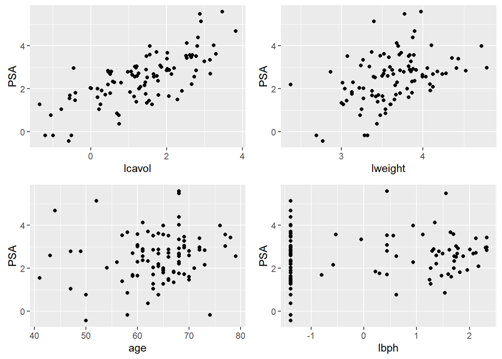

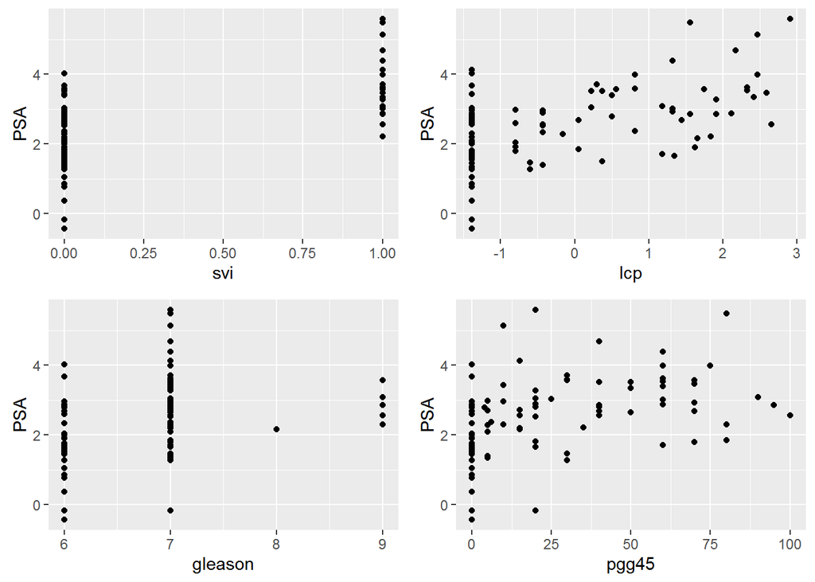

### Analise de correlação das variáveis

Abaixo estão as correlações entre as váriaveis numéricas presente nos dados.

```r
nums <- sapply(dados, is.numeric)
cor(dados[,nums])
```

```
##            lcavol    lweight       age         lbph         svi
## lcavol  1.0000000 0.28052138 0.2249999  0.027349703  0.53884500
## lweight 0.2805214 1.00000000 0.3479691  0.442264399  0.15538490
## age     0.2249999 0.34796911 1.0000000  0.350185896  0.11765804
## lbph    0.0273497 0.44226440 0.3501859  1.000000000 -0.08584324
## svi     0.5388450 0.15538490 0.1176580 -0.085843238  1.00000000
## lcp     0.6753105 0.16453714 0.1276678 -0.006999431  0.67311118
## gleason 0.4324171 0.05688209 0.2688916  0.077820447  0.32041222
## pgg45   0.4336522 0.10735379 0.2761124  0.078460018  0.45764762
## lpsa    0.7344603 0.43331938 0.1695928  0.179809404  0.56621822
##                  lcp    gleason      pgg45      lpsa
## lcavol   0.675310484 0.43241706 0.43365225 0.7344603
## lweight  0.164537142 0.05688209 0.10735379 0.4333194
## age      0.127667752 0.26889160 0.27611245 0.1695928
## lbph    -0.006999431 0.07782045 0.07846002 0.1798094
## svi      0.673111185 0.32041222 0.45764762 0.5662182
## lcp      1.000000000 0.51483006 0.63152825 0.5488132
## gleason  0.514830063 1.00000000 0.75190451 0.3689868
## pgg45    0.631528246 0.75190451 1.00000000 0.4223159
## lpsa     0.548813175 0.36898681 0.42231586 1.0000000
```

Graficamente:

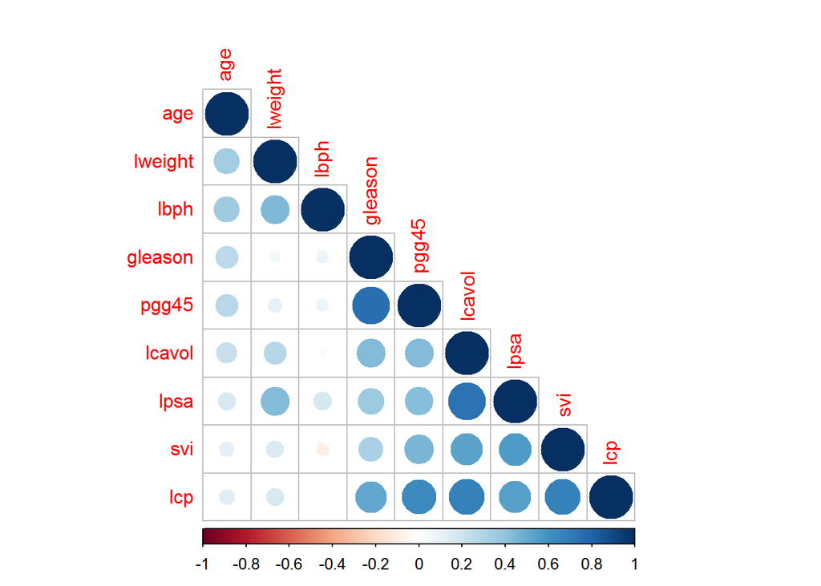

Com isso, nós podemos visualizar o nivel correlação da variavel lpsa com as demais preditores e escolher os preditores que serão usados no modelo. lcavol possue uma correlação positiva forte com a variável resposta (lpsa) por isso ela será importante no modelo, serão usados também as variáveis svi e lcp.

### Conclusões das analises

##### **1. Há evidência de relação entre os preditores e a variável alvo?**

Sim, de acordo com o gráfico de correlações, vemos que todos os preditores possuem algum tipo de relação com a variável resposta ipsa.

##### **2. Havendo relação, quão forte é essa relação?**

O nível dessa relação vária de acordo com o preditor. As variáveis ‘iweight’, ‘ibph’ e ‘glesson’ possuem uma relação fraca com a variável ipsa; ‘svi e ’icp’ possuem um releção moderada e ‘lcavol’ possue uma relação forte (não tão forte quanto o ideal).

##### **3. Que variável parece contribuir mais?**

‘lcavol’ é a que mais parece que irá contribuir com o modelo por causa da sua correlação.

##### **4. A relação sugere um modelo de regressão linear?**

Sim, pois há algumas váriaveis que possuem uma boa relação com a variável a variável resposta e que podem ser usadas no modelo.

## Regressão Linear

### Treinando o modelo

A variáveis de interesse que escolhi foram lcavol, svi e lcp. Para o treinamento do modelo, serão usados os dados de treino (dados_treino).

```r
#obtendo a regressão linear
reg_linear <- lm(lpsa ~ lcavol+svi+lcp, data = dados_treino)

#sumário do modelo
summary(reg_linear)
```

```
##
## Call:
## lm(formula = lpsa ~ lcavol + svi + lcp, data = dados_treino)
##
## Residuals:
##     Min      1Q  Median      3Q     Max
## -1.7015 -0.5090  0.1243  0.5160  1.6985
##
## Coefficients:
##             Estimate Std. Error t value Pr(>|t|)
## (Intercept)   1.3722     0.1952   7.030 1.77e-09 ***
## lcavol        0.6754     0.1144   5.903 1.55e-07 ***
## svi           0.7290     0.3296   2.212   0.0306 *
## lcp          -0.1395     0.1103  -1.265   0.2104
## ---
## Signif. codes:  0 '***' 0.001 '**' 0.01 '*' 0.05 '.' 0.1 ' ' 1
##
## Residual standard error: 0.8093 on 63 degrees of freedom
## Multiple R-squared:  0.5714, Adjusted R-squared:  0.551
## F-statistic:    28 on 3 and 63 DF,  p-value: 1.256e-11
```

### Realizando previsões

Para obter as previsões do modelo, serão usados os dados de teste (dados_teste)

```r
#predições
predicoes <- predict(reg_linear, select(dados_teste,lcavol, svi, lcp))

#dataframe com as predições
lm_predicoes <- data.frame(pred = predicoes, obs = dados_teste$lpsa)
```

Gráfico de valores observados versus valores previstos:

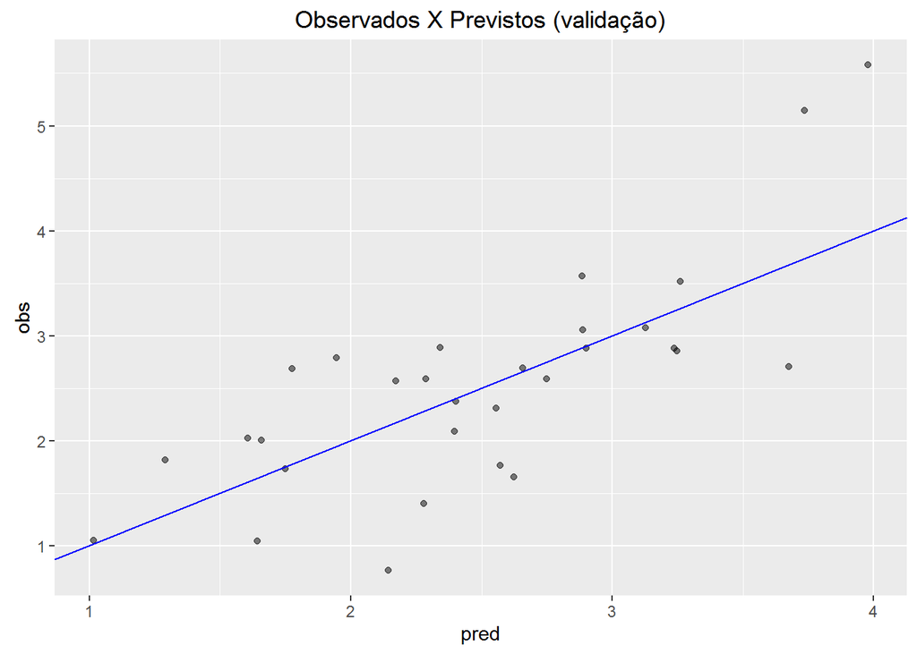

```r
ggplot(lm_predicoes, aes(x = pred, y = obs)) + geom_point(alpha = 0.5, position = position_jitter(width=0.2)) + geom_abline(colour = "blue") + ggtitle("Observados X Previstos (validação)")
```

### Resíduos na validação

Obtendo os resíduos.

```r
#resíduos
residuos = dados_teste$lpsa - predicoes
```

Gráfico de predições versus resíduous:

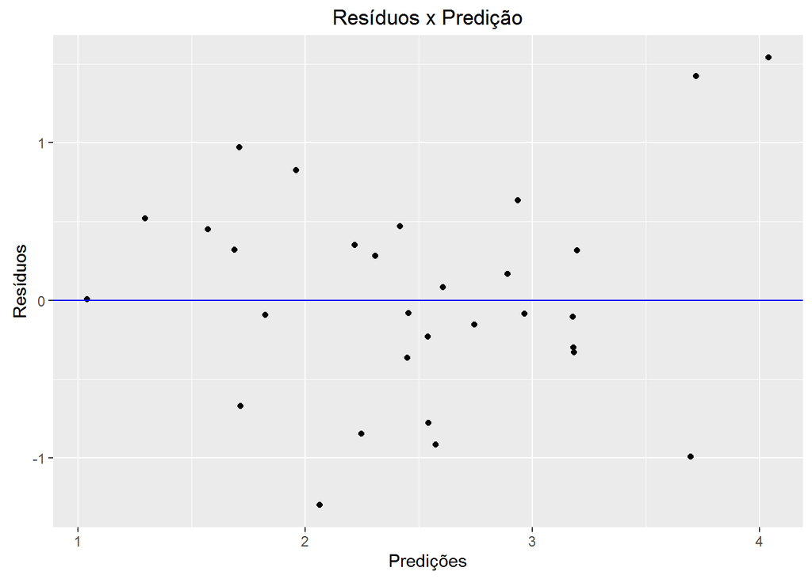

```r
qplot(predicoes, residuos, ylab = "Resíduos", xlab = "Predições") +
  geom_hline(yintercept = 0, color='blue') + ggtitle("Resíduos x Predição")
```

### Calculando o RMSE

```r
#mean squared error
RMSE(predicoes, dados_teste$lpsa)
```

```
## [1] 0.6654602
```

## Modelo LASSO

### Seleção de preditores

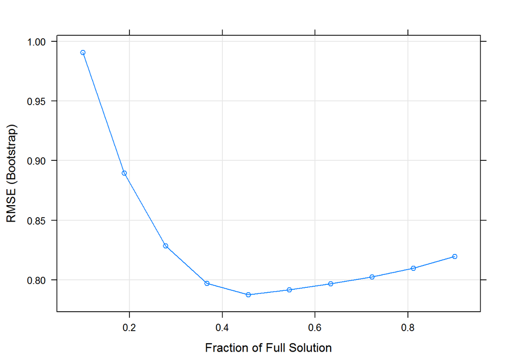

```r
lasso.fit <- train(lpsa ~ ., data=select(dados_treino, lcavol, lweight, age, lbph, svi, lcp, gleason, pgg45, lpsa), method='lasso', metric='RMSE',tuneLength=10)

plot(lasso.fit)
```

```r
lasso.fit
```

```
## The lasso
##
## 67 samples
##  8 predictor
##
## No pre-processing
## Resampling: Bootstrapped (25 reps)
## Summary of sample sizes: 67, 67, 67, 67, 67, 67, ...
## Resampling results across tuning parameters:
##
##   fraction   RMSE       Rsquared   RMSE SD     Rsquared SD
##   0.1000000  0.9908191  0.5133721  0.14466422  0.08348048
##   0.1888889  0.8895641  0.5285102  0.12995545  0.08388345
##   0.2777778  0.8285100  0.5497427  0.10613810  0.09215920
##   0.3666667  0.7971808  0.5686188  0.08475202  0.09752809
##   0.4555556  0.7874478  0.5791158  0.07055597  0.09504124
##   0.5444444  0.7916912  0.5809974  0.06848311  0.09403569
##   0.6333333  0.7967575  0.5804748  0.07384620  0.09439893
##   0.7222222  0.8024052  0.5789428  0.07921055  0.09294697
##   0.8111111  0.8098070  0.5767857  0.08429795  0.09280308
##   0.9000000  0.8196492  0.5734660  0.08881463  0.09468913
##
## RMSE was used to select the optimal model using  the smallest value.
## The final value used for the model was fraction = 0.4555556.
```

### Importância das variáveis para o modelo LASSO

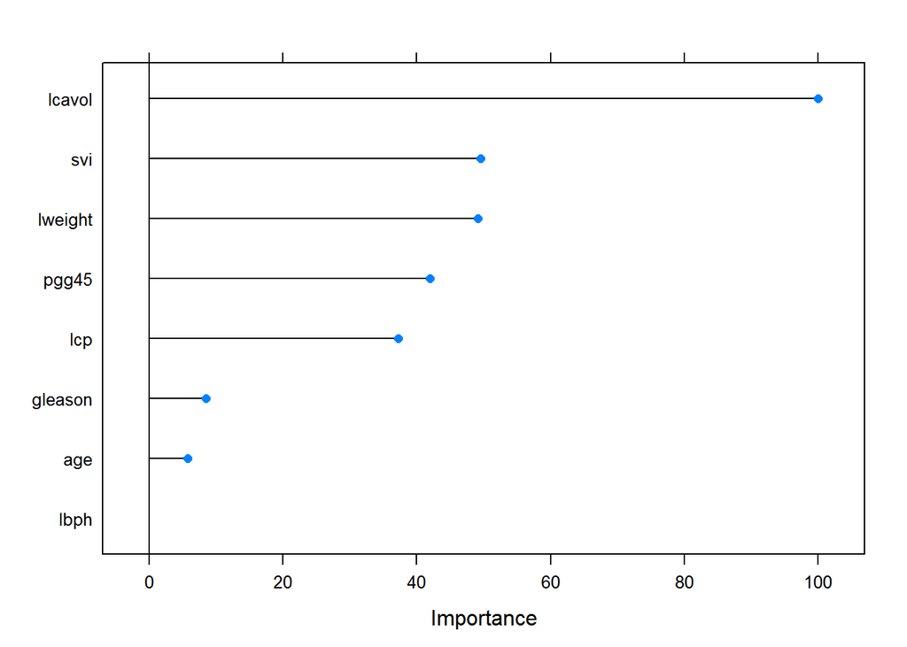

```r
plot(varImp(lasso.fit))
```

### Realizando previsões com o modelo LASSO

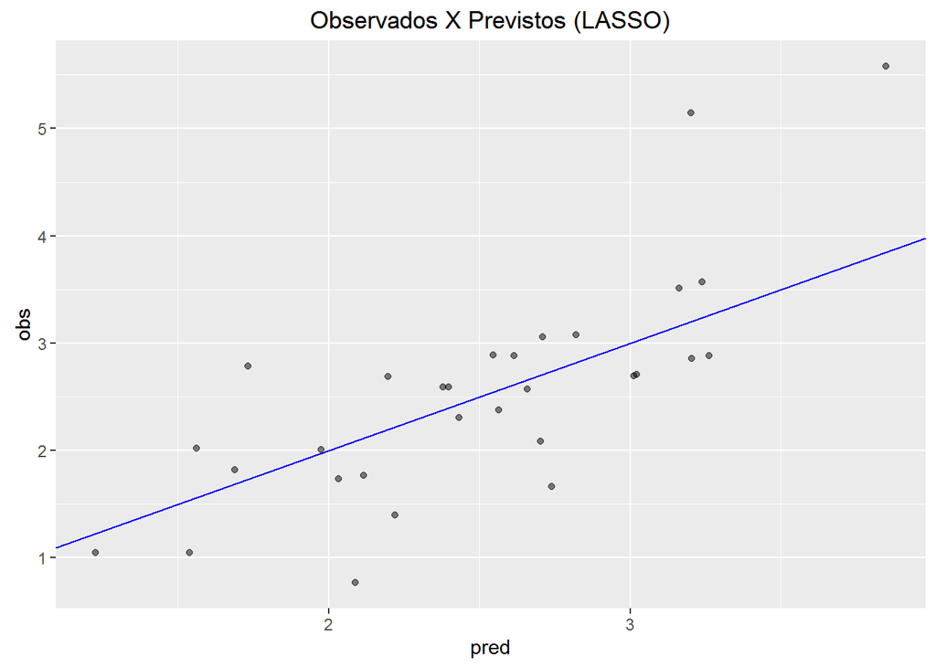

```r
lasso_predicoes <- predict(lasso.fit, select(dados_teste,lcavol, lweight, age, lbph, svi, lcp, gleason, pgg45))

la_predicoes <- data.frame(pred = lasso_predicoes, obs = dados_teste$lpsa)

ggplot(la_predicoes, aes(x = pred, y = obs)) + geom_point(alpha = 0.5, position = position_jitter(width=0.2)) + geom_abline(colour = "blue") + ggtitle("Observados X Previstos (LASSO)")
```

### Calculando o RMSE no modelo LASSO

```r
#mean squared error
RMSE(lasso_predicoes, dados_teste$lpsa)
```

```
## [1] 0.67461
```

## Comparando os modelos

Agora, iremos comparar os resultados obtidos entre os dois modelos utilizando o RMSE como métrica de avaliação

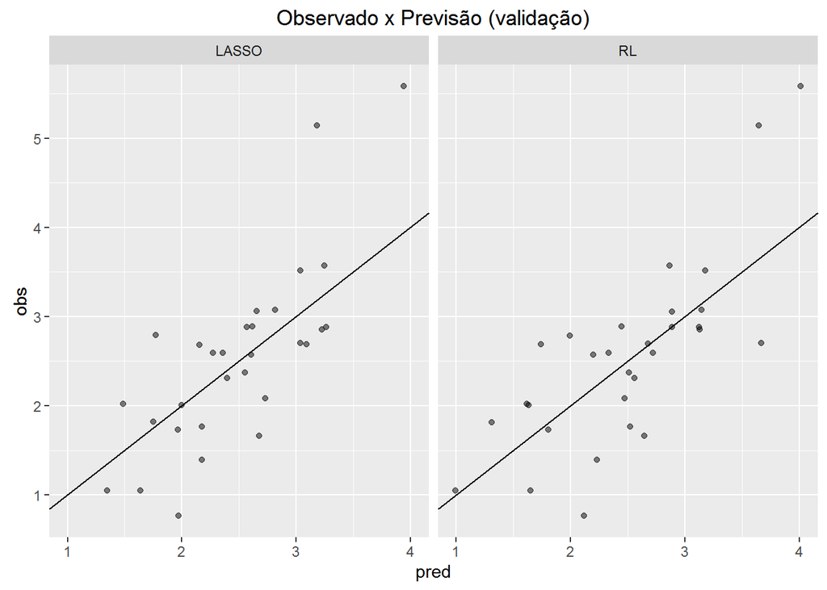

```r
lm_predicoes$model <- "RL"
la_predicoes$model <- "LASSO"

compare <- rbind(lm_predicoes, la_predicoes)

ggplot(compare, aes(x = pred, y = obs)) +
  geom_point(alpha = 0.5, position = position_jitter(width=0.2)) +
  facet_grid(. ~ model) +
  geom_abline() +
  ggtitle("Observado x Previsão (validação)")
```

```r
#RMSE - Regressão Linear
RMSE(predicoes, dados_teste$lpsa)
```

```
## [1] 0.6654602
```

```r
#RMSE - Modelo LASSO
RMSE(lasso_predicoes, dados_teste$lpsa)
```

```
## [1] 0.67461
```

### Conclusão

Analisando os resultados apresentados pelos dois modelos, vemos que ambos se ajustaram bem aos valores de testes usados para fazer previsões. Os RMSE’s produzidos pelos dois modelos são baixos e praticamente iguais. Isso nos mostra que os modelos não são tão diferentes um do outro, pois produzem resultados semelhantes.